# Defaunation impacts carbon storage in tropical forests

Carolina Bello, Mauro Galetti, Marco A. Pizo, Luiz Fernando S. Magnago, Mariana Ferreira Rocha , Renato A. F. Lima, Carlos A. Peres, Otso Ovaskainen, and Pedro Jordano

Thursday, July 23, 2015

### SIMULATION CODE

This is the code for the defaunation simulations function `simulation7porcA` with one example community of the Atlantic Forest. The aim is to see how carbon stock will change in the defaunated scenario (loss of tree species with seed size >= 12.0 mm +/-1.1mm) and, in the random extinction scenario (i.e., tree species removal independent of seed size).

The imputs are the community data merged with the trait data `prove_community.csv` and, with the initial cabon `carbon_proxi` already calculated

The code presents the function, explaining each step. Then, we apply it to the community data (here we use just one community but it can be applied to the 31 communities in the same way). Finally the code produces a diagnostic plot of the carbon balance .

### Simulation function

Imputs: x=Data of the communities. c=“Carbonproxi” This function selected endangered species to be removed and then selects species to replace them. Then, it merge the defaunated community with the new replaced community.

The prodecure is repeated for created the random community.

Finally the function calculated the diference between the inicial carbon and the new comunity carbon.

It does 1000 repetitions for each percentage 10,20…100%.

```r
simulation7porcA=function(x,Carbon.name="Carbonproxi"){

  c=which(names(x)==Carbon.name)
  #remove sp whitout data
  x=x[-which(is.na(x[,c])),]

  noN=which(x$N==0)
  if (length(noN)>0){x=x[-noN,]}

  #inicial carbon
  carbon=sum(x[,c])

  #assing weigths
  #for the replacements " more abundance  spp has more probability to enter in the replacement game"
  maxN=max(x$N)
  minN=min(x$N)

  x$wN=(x$N-minN)/(maxN-minN)

  #weigths  for extinction, "larger seed species has more probability to go extinct "
  maxseed=max(x$seeddiam,na.rm=T)
  minseed=min(x$seeddiam,na.rm=T)

  x$wseed=(x$seeddiam-minseed)/(maxseed-minseed)
  x$wseed[which(is.na(x$wseed))]=0

  x$nabw=x$AB/sum(x$AB)

  # generated interval to set endangered ( 12mm +/- 1.1mm )
  interval=round(runif(100, 11,13),3)

  #define porcentage of defauantion
  porc=c(10,20,30,40,50,60,70,80,90,100)

  #set empty  objects  to fill in the simulation
  sim3=NULL


  #select species to remove from 10% to 100% of the number of endangered species in each community
  for (i in porc){# i number of sps to remove , max remove 100% of endangered sps

    sim4=NULL

    #For each  number of species to remove we made 1000 simulations

    for (j in 1:1000){
      #identify endangered zoochoric species at a given value of the interval (seed diameter= 12mm +/- 1.1mm)

      limit=sample(interval,1)
      endangered=which(x$sindr=="zoochoric"& x$seeddiam>=limit)
      maxdanger=length(endangered)
      npor=ceiling((maxdanger*i)/100)
      print(paste0(npor,"/",maxdanger,"=",i,"%",limit,unique(x$SiteCode)))

      all.sp=1:nrow(x)

      weightout=x$wseed[endangered]

      #select sps to remove in defanated scenario and in random scenario
      random=sample(all.sp,npor)
      if (length(endangered)==1){defaunated=endangered}else{
        defaunated=sample(endangered,npor,prob=weightout)}


      #created community to replace  erase extinct species
      x.replace=all.sp[-defaunated]

      # weights to replace more abundant specie has higher probability to replace
      weight=x$wN[x.replace]*(1-x$wseed[x.replace])
      # we will replace the same number of ind/ha (DA). and basal area (DoA) from the remain community
      nind=ceiling(sum(x$DA[defaunated]))
      nAB=sum(x$DoA[defaunated])
      ABprom=nAB/nind

      #replace community in defaunates scenario
      # we select indivuals from the remain community

      x.replace2=sample(x.replace,nind,prob=weight,replace=TRUE)
      replace.data=as.data.frame(table(x.replace2))
      y=unique(x.replace2)
      y=y[order(y)]


      newdata=x[y,]
      # assing the number of ind  and DoA selected for each sp
      newdata$DA=replace.data[,2]
      newdata$nabw=newdata$AB/sum(newdata$AB)
      newdata$DoA=nAB*newdata$nabw



      # calculate Biomass by carbon proxi equation wood x DAP x max height
      newdata$biomassproxi= exp(-0.679288+(0.967049*(log(newdata$DoA*newdata$wooden*newdata$Tre.size.max))))

      # calculate carbon
      newdata$Carbonproxi=(0.60*newdata$biomassproxi)*0.48

      #create a unique communitY  AFTER  defaunation extinction
      comu.defaunated=x[-defaunated,]
      comu.defaunated=rbind(comu.defaunated,newdata)
      length(unique(comu.defaunated$search.str))


      ######CONSTRUCT RANDOM COMMUNITY

      nindA=ceiling(sum(x$DA[random]))
      nABA=sum(x$DoA[random])
      ABpromA=nABA/nindA

      #replace community in random scenario
      # we select indivuals from the replace community
      if (length(which(all.sp %in% random))!=0){
        x.replaceA=all.sp[-which(all.sp %in% random)]
      }else{x.replaceA=all.sp[-random]}


      weightA=x$wN[x.replaceA]
      # Select nindA =ind of the remaning community  acording to their abundance
      x.replace2A=sample(x=x.replaceA,size=nindA,prob=weightA,replace=TRUE)

      replace.dataA=as.data.frame(table(x.replace2A))
      yA=unique(x.replace2A)
      yA=yA[order(yA)]

      # Generate subset of replacement species
      newdataA=x[yA,]
      newdataA$DA=replace.dataA[,2]
      newdataA$nabw=newdataA$AB/sum(newdataA$AB)
      newdataA$DoA=nABA*newdataA$nabw



      # calculate Biomass by proxi relation wood x DAP in ton
      # I tried DAP and AB and DAP  was clouser to Chaves estimations


      newdataA$biomassproxi=exp(-0.679288+(0.967049*(log(newdataA$DoA*newdataA$wooden*newdataA$Tre.size.max))))

#       # calculate carbon
      newdataA$Carbonproxi=(0.583*newdataA$biomassproxi)*0.485


      #create a unique community  AFTER random extinction
      comu.random=x[-random,]
      comu.random=rbind(comu.random,newdataA)
      length(unique(comu.random$search.str))


      ####  carbon in new communities (ton/ha)
      carbon.random=sum(comu.random[,c])
      carbon.defaunated=sum(comu.defaunated[,c])


      #### Find the diference in  carbon respect to the initial community
      random.loss=((carbon.random-carbon))
      defaunated.loss=((carbon.defaunated- carbon))

      # Find the carbon diference  between defanated and random scenarios
      diference=(carbon.random-carbon.defaunated)#/carbon.random)*100


      result.carbon=cbind(i,npor,carbon, carbon.random,carbon.defaunated,random.loss,defaunated.loss,diference)

      sim4=rbind(sim4,result.carbon)

    }
    sim3=rbind(sim3,colMeans(sim4))

  }

  return(sim3)

}
```

### Apply the function for the community data

```r
# coerce to list structure

abundance.list=split(x, x$SiteCode)

#apply the function

simulacionesproxi3_1000=laply(abundance.list, simulation7porcA, Carbon.name="Carbonproxi")
```

### Diagnostic plot

Trajectory of the dafaunated scenario (red) and random scenario( blue).

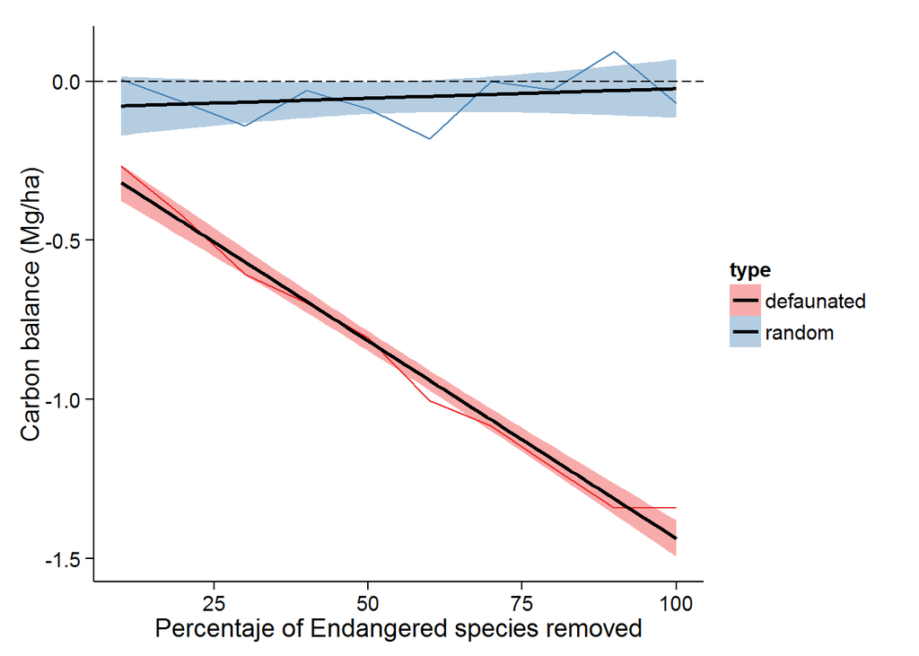